# Customising the plot

## The returned object is a ggplot

Every call to `mirror_slope_plot()` returns a standard `ggplot` object. This means you customise it with the same `+` syntax you already use, rather than learning package-specific options.

[output not shown]

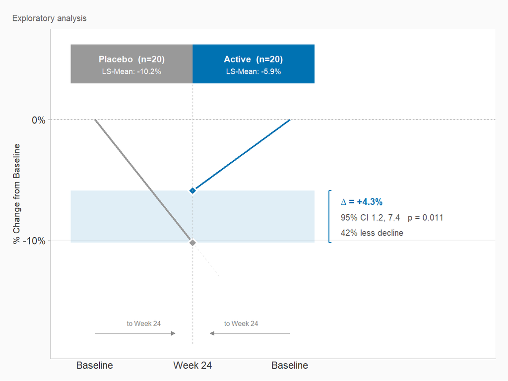

```r
p <- mirror_slope_plot(
  md,
  trt_colors      = mirror_palette("colorblind"),
  show_difference = TRUE,
  show_slowing    = TRUE
)

p +
  labs(subtitle = "Exploratory analysis") +
  theme(
    plot.background = element_rect(fill = "grey98", color = NA),
    axis.text       = element_text(size = 11)
  )
```

## Palettes

`mirror_palette()` returns a two-colour vector for the reference and comparator arms. Three palettes are provided. The colourblind-safe palette is recommended for publication.

```r
mirror_palette("default")
```

```
#> [1] "#6B6B6B" "#005CB9"
```

```r
mirror_palette("colorblind")
```

```
#> [1] "#999999" "#0072B2"
```

```r
# Reverse if you want the stronger colour on the reference arm
mirror_palette("colorblind", reversed = TRUE)
```

```
#> [1] "#0072B2" "#999999"
```

You may also pass any named or unnamed length-two vector of your own colours:

[output not shown]

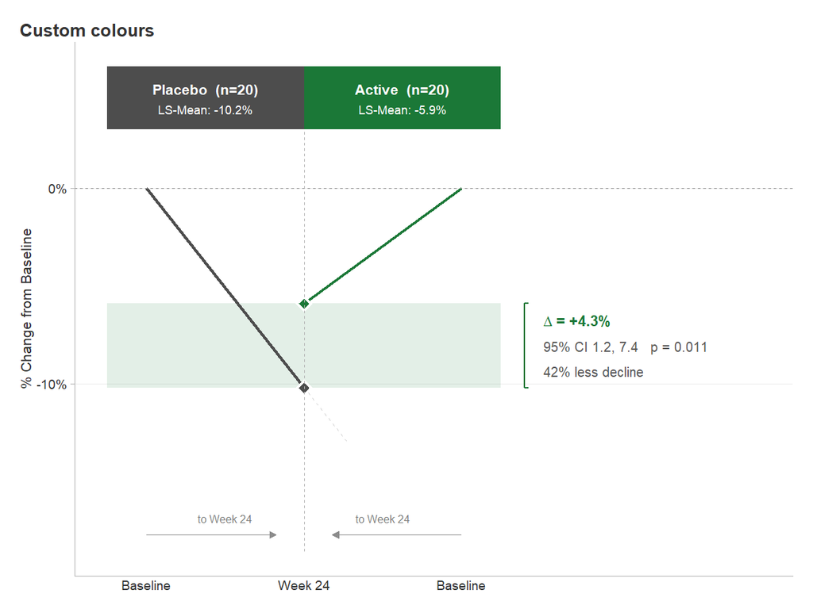

```r
mirror_slope_plot(
  md,
  trt_colors      = c("#4D4D4D", "#1B7837"),
  show_difference = TRUE,
  show_slowing    = TRUE,
  title           = "Custom colours"
)
```

## Font scaling

`base_size` scales all text proportionally. Increase it for slides or posters, decrease it for dense multi-panel figures.

[output not shown]

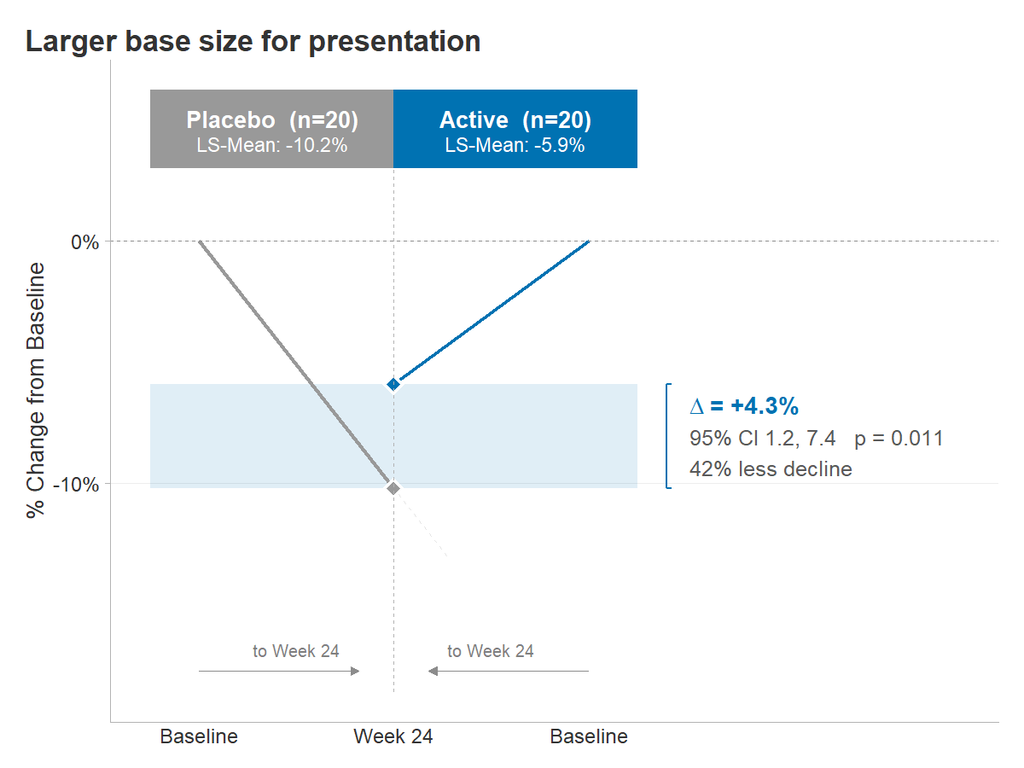

```r
mirror_slope_plot(
  md,
  trt_colors      = mirror_palette("colorblind"),
  show_difference = TRUE,
  show_slowing    = TRUE,
  base_size       = 14,
  title           = "Larger base size for presentation"
)
```

## Custom terminology

[figure not shown]

```r
mirror_slope_plot(
  md,
  trt_colors      = mirror_palette("colorblind"),
  show_slowing    = TRUE,
  outcome_label   = "worsening",
  title           = "Custom outcome terminology"
)
```

## Combining multiple panels

The package renders one two-arm comparison per plot. To show several endpoints together, build each plot separately and combine them with a layout package such as **patchwork**. This keeps `mirrorslope` focused while giving you full control over the arrangement.

[output not shown]

[output cut: 15 more lines]

[output not shown]

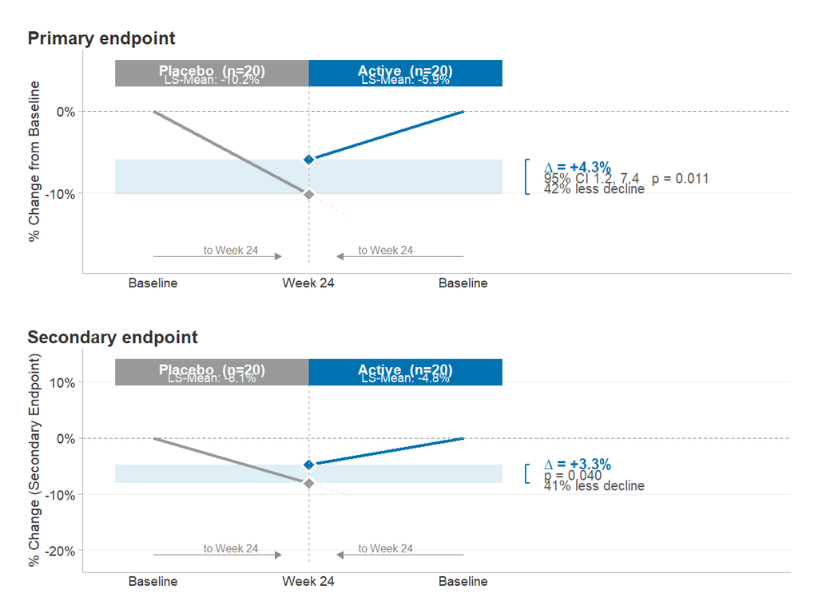

```r
library(patchwork)

# A second endpoint
set.seed(9)
df2 <- df
df2$AVAL <- c(rbind(rep(0, n),
                    c(rnorm(n / 2, -8, 4), rnorm(n / 2, -5, 4))))
md2 <- prep_mirror_data(df2, trt_levels = c("Placebo", "Active"),
                        time_baseline = "Baseline", time_endpoint = "Week 24",
                        value_label = "% Change (Secondary Endpoint)")
md2 <- add_summary(md2, c("Placebo" = -8.1, "Active" = -4.8),
                   stat_label = "LS-Mean")
md2 <- add_difference(md2, estimate = 3.3, p_value = 0.04)

pa <- mirror_slope_plot(md,  trt_colors = mirror_palette("colorblind"),
                        show_difference = TRUE, show_slowing = TRUE,
                        title = "Primary endpoint")
pb <- mirror_slope_plot(md2, trt_colors = mirror_palette("colorblind"),
                        show_difference = TRUE, show_slowing = TRUE,
                        title = "Secondary endpoint")

pa / pb
```

For a shared y-axis across panels, set the same `y_lim` on each plot so the scales align.

## Saving for publication

Pass `save_path` to write the figure directly, or use `ggplot2::ggsave()` on the returned object. A vector format (PDF or SVG) is preferable for print; raster formats should be at least 300 dpi.

```r
mirror_slope_plot(
  md,
  trt_colors      = mirror_palette("colorblind"),
  show_difference = TRUE,
  show_slowing    = TRUE,
  save_path       = "figure1.pdf",
  width           = 9,
  height          = 6
)
```